# Simulation Study Analysis Report

**Generated:** 2025-12-30 20:35:32

**Data Source:** C:\Users\KevinJoy\OneDrive - Herren Associates\Constrained-Penalized Regression Paper - General\penalized_constrained\scripts\output_v2\simulation_results.parquet

**Total Observations:** 60,750 (converged models only)

## Executive Summary

#### Overall Winner

PCReg_CV_Tight

#### Best Mean SSPE

0.0430

#### Total Scenarios

6,075

#### Models Compared

10

## Overall Model Performance

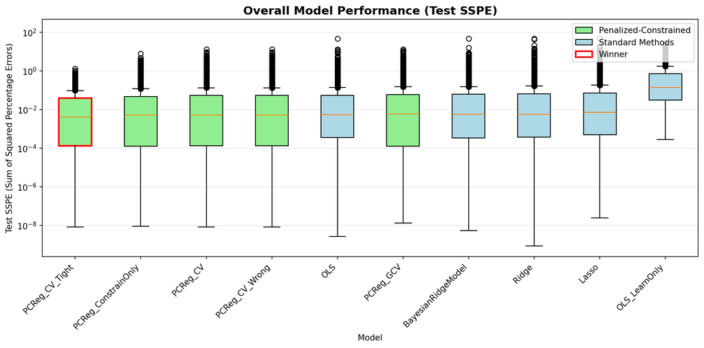

### Descriptive Statistics

| Rank | Model | Mean SSPE | Std SSPE | Median SSPE | Count | Win Count | Win % |
| --- | --- | --- | --- | --- | --- | --- | --- |
| 1 | PCReg_CV_Tight | 0.0430 | 0.0910 | 0.0041 | 6075 | 1516 | 25.0% |
| 2 | PCReg_ConstrainOnly | 0.0798 | 0.2637 | 0.0052 | 6075 | 1187 | 19.5% |
| 3 | PCReg_CV | 0.1092 | 0.4354 | 0.0052 | 6075 | 277 | 4.6% |
| 4 | PCReg_CV_Wrong | 0.1094 | 0.4358 | 0.0052 | 6075 | 220 | 3.6% |
| 5 | OLS | 0.1146 | 0.7557 | 0.0055 | 6075 | 646 | 10.6% |
| 6 | PCReg_GCV | 0.1220 | 0.4800 | 0.0060 | 6075 | 366 | 6.0% |
| 7 | BayesianRidgeModel | 0.1409 | 0.7857 | 0.0057 | 6075 | 516 | 8.5% |
| 8 | Ridge | 0.1580 | 1.0644 | 0.0058 | 6075 | 304 | 5.0% |
| 9 | Lasso | 0.2014 | 1.0043 | 0.0072 | 6075 | 720 | 11.9% |
| 10 | OLS_LearnOnly | 0.8658 | 2.5266 | 0.1410 | 6075 | 323 | 5.3% |

## DOE Statistical Analysis

Rigorous statistical analysis using Design of Experiments methodology to determine if differences between models are statistically significant and practically meaningful.

### Repeated Measures ANOVA

Tests whether there is a statistically significant difference in performance across models, accounting for the repeated measures structure (all models fit on the same data).

**F-statistic:** 576.42

**p-value:** 0.0000 ***

**Effect Size (generalized η²):** 0.0636 (medium)

**Interpretation:** Model choice explains 6.4% of variance in test SSPE.

### Pairwise Comparisons (Holm-Bonferroni Corrected)

Statistical comparisons between specific model pairs with effect sizes (Hedges' g). Negative g means the first model has lower SSPE (better performance).

[output not shown]

### Win Rate Analysis (PCReg_CV vs OLS)

How often does PCReg_CV achieve lower test SSPE than OLS across scenarios?

**Overall Win Rate:** 56.9% (3455/6075)

**Binomial Test p-value:** 0.0000

PCReg_CV significantly outperforms OLS overall (p < 0.05)

#### Win Rates by Design Factor

| Factor | Level | Win Rate | Significant? |
| --- | --- | --- | --- |
| cv_error | 0.01 | 70.9% | * |
| cv_error | 0.1 | 52.4% | * |
| cv_error | 0.2 | 47.3% |  |
| target_correlation | 0.0 | 59.6% | * |
| target_correlation | 0.5 | 54.9% | * |
| target_correlation | 0.9 | 56.1% | * |
| learning_rate | 0.85 | 56.5% | * |
| learning_rate | 0.9 | 55.7% | * |
| learning_rate | 0.95 | 58.4% | * |
| rate_effect | 0.8 | 57.4% | * |
| rate_effect | 0.85 | 55.8% | * |
| rate_effect | 0.9 | 57.4% | * |
| n_lots | 5.0 | 61.5% | * |
| n_lots | 10.0 | 57.7% | * |
| n_lots | 30.0 | 51.4% |  |

## Recommendations: When to Use Each Method

### Key Findings:

- **PCReg_CV_Tight** (well-specified constraints) achieves the best performance when bounds are known
- **PCReg_CV_Wrong** shows robustness - misspecified constraints still competitive
- **PCReg_ConstrainOnly** often matches or beats PCReg_CV - penalty may not always help
- **OLS_LearnOnly** (single predictor) performs poorly - rate effect is important

## Analysis by CV Error

Values: [np.float64(0.01), np.float64(0.1), np.float64(0.2)]

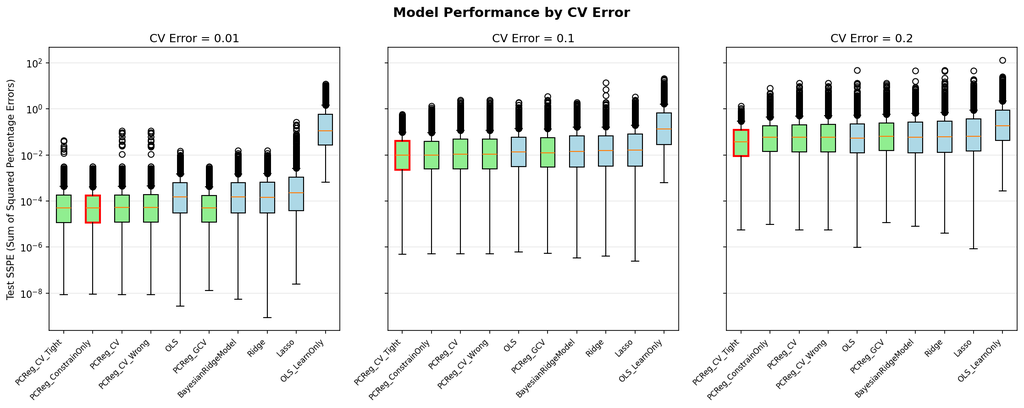

### Winners by CV Error

| CV Error | Winner | Mean SSPE |
| --- | --- | --- |
| 0.01 | PCReg_ConstrainOnly | 0.0002 |
| 0.1 | PCReg_CV_Tight | 0.0380 |
| 0.2 | PCReg_CV_Tight | 0.0906 |

### Mean test_sspe by CV Error and Model

| model_name cv_error | BayesianRidgeModel | Lasso | OLS | OLS_LearnOnly | PCReg_CV | PCReg_CV_Tight | PCReg_CV_Wrong | PCReg_ConstrainOnly | PCReg_GCV | Ridge |
| --- | --- | --- | --- | --- | --- | --- | --- | --- | --- | --- |
| 0.0100 | 0.0006 | 0.0023 | 0.0006 | 0.6946 | 0.0005 | 0.0003 | 0.0005 | 0.0002 | 0.0002 | 0.0006 |
| 0.1000 | 0.0703 | 0.0970 | 0.0606 | 0.8061 | 0.0682 | 0.0380 | 0.0680 | 0.0445 | 0.0717 | 0.0810 |
| 0.2000 | 0.3518 | 0.5049 | 0.2827 | 1.0968 | 0.2588 | 0.0906 | 0.2596 | 0.1948 | 0.2942 | 0.3924 |

### Detailed Statistics

**Click to expand full statistics table**

| cv_error | model_name | count | mean | std | min | 25% | 50% | 75% | max |
| --- | --- | --- | --- | --- | --- | --- | --- | --- | --- |
| 0.0100 | BayesianRidgeModel | 2025.0000 | 0.0006 | 0.0011 | 0.0000 | 0.0000 | 0.0001 | 0.0006 | 0.0154 |
|  | Lasso | 2025.0000 | 0.0023 | 0.0124 | 0.0000 | 0.0000 | 0.0002 | 0.0011 | 0.2632 |
|  | OLS | 2025.0000 | 0.0006 | 0.0011 | 0.0000 | 0.0000 | 0.0001 | 0.0006 | 0.0149 |
|  | OLS_LearnOnly | 2025.0000 | 0.6946 | 1.4615 | 0.0007 | 0.0269 | 0.1110 | 0.5951 | 12.2855 |
|  | PCReg_CV | 2025.0000 | 0.0005 | 0.0048 | 0.0000 | 0.0000 | 0.0001 | 0.0002 | 0.1124 |
|  | PCReg_CV_Tight | 2025.0000 | 0.0003 | 0.0016 | 0.0000 | 0.0000 | 0.0001 | 0.0002 | 0.0425 |
|  | PCReg_CV_Wrong | 2025.0000 | 0.0005 | 0.0049 | 0.0000 | 0.0000 | 0.0001 | 0.0002 | 0.1124 |
|  | PCReg_ConstrainOnly | 2025.0000 | 0.0002 | 0.0003 | 0.0000 | 0.0000 | 0.0000 | 0.0002 | 0.0031 |
|  | PCReg_GCV | 2025.0000 | 0.0002 | 0.0003 | 0.0000 | 0.0000 | 0.0001 | 0.0002 | 0.0031 |
|  | Ridge | 2025.0000 | 0.0006 | 0.0011 | 0.0000 | 0.0000 | 0.0001 | 0.0006 | 0.0152 |
| 0.1000 | BayesianRidgeModel | 2025.0000 | 0.0703 | 0.1620 | 0.0000 | 0.0030 | 0.0138 | 0.0663 | 1.9576 |
|  | Lasso | 2025.0000 | 0.0970 | 0.2339 | 0.0000 | 0.0032 | 0.0159 | 0.0803 | 3.3224 |
|  | OLS | 2025.0000 | 0.0606 | 0.1352 | 0.0000 | 0.0032 | 0.0137 | 0.0591 | 1.8854 |
|  | OLS_LearnOnly | 2025.0000 | 0.8061 | 1.8444 | 0.0006 | 0.0288 | 0.1361 | 0.6657 | 21.0110 |
|  | PCReg_CV | 2025.0000 | 0.0682 | 0.1812 | 0.0000 | 0.0024 | 0.0107 | 0.0480 | 2.4207 |
|  | PCReg_CV_Tight | 2025.0000 | 0.0380 | 0.0663 | 0.0000 | 0.0022 | 0.0099 | 0.0399 | 0.5747 |
|  | PCReg_CV_Wrong | 2025.0000 | 0.0680 | 0.1813 | 0.0000 | 0.0024 | 0.0107 | 0.0477 | 2.4247 |
|  | PCReg_ConstrainOnly | 2025.0000 | 0.0445 | 0.1020 | 0.0000 | 0.0025 | 0.0100 | 0.0385 | 1.3473 |
|  | PCReg_GCV | 2025.0000 | 0.0717 | 0.1878 | 0.0000 | 0.0029 | 0.0126 | 0.0554 | 3.4317 |
|  | Ridge | 2025.0000 | 0.0810 | 0.3849 | 0.0000 | 0.0033 | 0.0153 | 0.0683 | 13.9635 |
| 0.2000 | BayesianRidgeModel | 2025.0000 | 0.3518 | 1.3255 | 0.0000 | 0.0123 | 0.0575 | 0.2683 | 46.4751 |
|  | Lasso | 2025.0000 | 0.5049 | 1.6821 | 0.0000 | 0.0146 | 0.0651 | 0.3618 | 46.5091 |
|  | OLS | 2025.0000 | 0.2827 | 1.2851 | 0.0000 | 0.0123 | 0.0529 | 0.2219 | 47.2520 |
|  | OLS_LearnOnly | 2025.0000 | 1.0968 | 3.6788 | 0.0003 | 0.0416 | 0.1845 | 0.8960 | 129.1258 |
|  | PCReg_CV | 2025.0000 | 0.2588 | 0.7072 | 0.0000 | 0.0137 | 0.0575 | 0.2070 | 13.4309 |
|  | PCReg_CV_Tight | 2025.0000 | 0.0906 | 0.1278 | 0.0000 | 0.0089 | 0.0379 | 0.1210 | 1.3050 |
|  | PCReg_CV_Wrong | 2025.0000 | 0.2596 | 0.7077 | 0.0000 | 0.0138 | 0.0575 | 0.2090 | 13.4309 |
|  | PCReg_ConstrainOnly | 2025.0000 | 0.1948 | 0.4213 | 0.0000 | 0.0143 | 0.0576 | 0.1849 | 7.9484 |
|  | PCReg_GCV | 2025.0000 | 0.2942 | 0.7804 | 0.0000 | 0.0158 | 0.0655 | 0.2412 | 13.4309 |
|  | Ridge | 2025.0000 | 0.3924 | 1.7793 | 0.0000 | 0.0127 | 0.0610 | 0.2897 | 47.1783 |

## Analysis by Correlation

Values: [np.float64(0.0), np.float64(0.5), np.float64(0.9)]

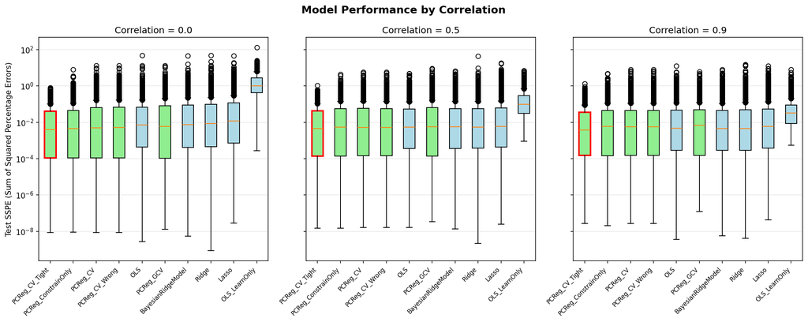

### Winners by Correlation

| Correlation | Winner | Mean SSPE |
| --- | --- | --- |
| 0.0 | PCReg_CV_Tight | 0.0408 |
| 0.5 | PCReg_CV_Tight | 0.0434 |
| 0.9 | PCReg_CV_Tight | 0.0447 |

### Mean test_sspe by Correlation and Model

| model_name target_correlation | BayesianRidgeModel | Lasso | OLS | OLS_LearnOnly | PCReg_CV | PCReg_CV_Tight | PCReg_CV_Wrong | PCReg_ConstrainOnly | PCReg_GCV | Ridge |
| --- | --- | --- | --- | --- | --- | --- | --- | --- | --- | --- |
| 0.0000 | 0.1902 | 0.2693 | 0.1485 | 2.1937 | 0.1374 | 0.0408 | 0.1383 | 0.0874 | 0.1568 | 0.2108 |
| 0.5000 | 0.1248 | 0.1930 | 0.0941 | 0.2872 | 0.1001 | 0.0434 | 0.0999 | 0.0803 | 0.1239 | 0.1351 |
| 0.9000 | 0.1077 | 0.1419 | 0.1012 | 0.1165 | 0.0900 | 0.0447 | 0.0900 | 0.0718 | 0.0854 | 0.1281 |

### Detailed Statistics

**Click to expand full statistics table**

| target_correlation | model_name | count | mean | std | min | 25% | 50% | 75% | max |
| --- | --- | --- | --- | --- | --- | --- | --- | --- | --- |
| 0.0000 | BayesianRidgeModel | 2025.0000 | 0.1902 | 1.2139 | 0.0000 | 0.0004 | 0.0074 | 0.0903 | 46.4751 |
|  | Lasso | 2025.0000 | 0.2693 | 1.3965 | 0.0000 | 0.0007 | 0.0115 | 0.1164 | 46.5091 |
|  | OLS | 2025.0000 | 0.1485 | 1.1889 | 0.0000 | 0.0004 | 0.0071 | 0.0684 | 47.2520 |
|  | OLS_LearnOnly | 2025.0000 | 2.1937 | 4.0028 | 0.0003 | 0.4244 | 1.0240 | 2.7327 | 129.1258 |
|  | PCReg_CV | 2025.0000 | 0.1374 | 0.5633 | 0.0000 | 0.0001 | 0.0050 | 0.0645 | 13.4309 |
|  | PCReg_CV_Tight | 2025.0000 | 0.0408 | 0.0839 | 0.0000 | 0.0001 | 0.0039 | 0.0404 | 0.7884 |
|  | PCReg_CV_Wrong | 2025.0000 | 0.1383 | 0.5634 | 0.0000 | 0.0001 | 0.0052 | 0.0665 | 13.4309 |
|  | PCReg_ConstrainOnly | 2025.0000 | 0.0874 | 0.3000 | 0.0000 | 0.0001 | 0.0044 | 0.0446 | 7.9484 |
|  | PCReg_GCV | 2025.0000 | 0.1568 | 0.6090 | 0.0000 | 0.0001 | 0.0058 | 0.0814 | 13.4309 |
|  | Ridge | 2025.0000 | 0.2108 | 1.3487 | 0.0000 | 0.0005 | 0.0085 | 0.0951 | 47.1783 |
| 0.5000 | BayesianRidgeModel | 2025.0000 | 0.1248 | 0.4298 | 0.0000 | 0.0004 | 0.0056 | 0.0563 | 6.5244 |
|  | Lasso | 2025.0000 | 0.1930 | 0.8377 | 0.0000 | 0.0004 | 0.0060 | 0.0602 | 18.4467 |
|  | OLS | 2025.0000 | 0.0941 | 0.3045 | 0.0000 | 0.0004 | 0.0053 | 0.0545 | 4.8220 |
|  | OLS_LearnOnly | 2025.0000 | 0.2872 | 0.5839 | 0.0009 | 0.0315 | 0.0994 | 0.2974 | 7.0115 |
|  | PCReg_CV | 2025.0000 | 0.1001 | 0.3282 | 0.0000 | 0.0001 | 0.0052 | 0.0575 | 5.7379 |
|  | PCReg_CV_Tight | 2025.0000 | 0.0434 | 0.0883 | 0.0000 | 0.0001 | 0.0044 | 0.0426 | 1.0406 |
|  | PCReg_CV_Wrong | 2025.0000 | 0.0999 | 0.3294 | 0.0000 | 0.0001 | 0.0051 | 0.0560 | 5.7379 |
|  | PCReg_ConstrainOnly | 2025.0000 | 0.0803 | 0.2352 | 0.0000 | 0.0001 | 0.0054 | 0.0566 | 4.4290 |
|  | PCReg_GCV | 2025.0000 | 0.1239 | 0.4687 | 0.0000 | 0.0001 | 0.0057 | 0.0647 | 9.1772 |
|  | Ridge | 2025.0000 | 0.1351 | 1.0603 | 0.0000 | 0.0004 | 0.0054 | 0.0572 | 44.0540 |
| 0.9000 | BayesianRidgeModel | 2025.0000 | 0.1077 | 0.4364 | 0.0000 | 0.0003 | 0.0044 | 0.0446 | 7.7968 |
|  | Lasso | 2025.0000 | 0.1419 | 0.6058 | 0.0000 | 0.0004 | 0.0059 | 0.0539 | 12.8673 |
|  | OLS | 2025.0000 | 0.1012 | 0.4539 | 0.0000 | 0.0003 | 0.0046 | 0.0476 | 12.7770 |
|  | OLS_LearnOnly | 2025.0000 | 0.1165 | 0.3646 | 0.0005 | 0.0084 | 0.0330 | 0.0873 | 7.7944 |
|  | PCReg_CV | 2025.0000 | 0.0900 | 0.3775 | 0.0000 | 0.0001 | 0.0056 | 0.0450 | 8.1085 |
|  | PCReg_CV_Tight | 2025.0000 | 0.0447 | 0.1001 | 0.0000 | 0.0001 | 0.0038 | 0.0354 | 1.3050 |
|  | PCReg_CV_Wrong | 2025.0000 | 0.0900 | 0.3778 | 0.0000 | 0.0001 | 0.0056 | 0.0444 | 8.1085 |
|  | PCReg_ConstrainOnly | 2025.0000 | 0.0718 | 0.2514 | 0.0000 | 0.0001 | 0.0058 | 0.0443 | 4.7624 |
|  | PCReg_GCV | 2025.0000 | 0.0854 | 0.3134 | 0.0000 | 0.0002 | 0.0067 | 0.0479 | 5.9548 |
|  | Ridge | 2025.0000 | 0.1281 | 0.6727 | 0.0000 | 0.0003 | 0.0046 | 0.0494 | 14.8769 |

## Analysis by Learning Rate

Values: [np.float64(0.85), np.float64(0.9), np.float64(0.95)]

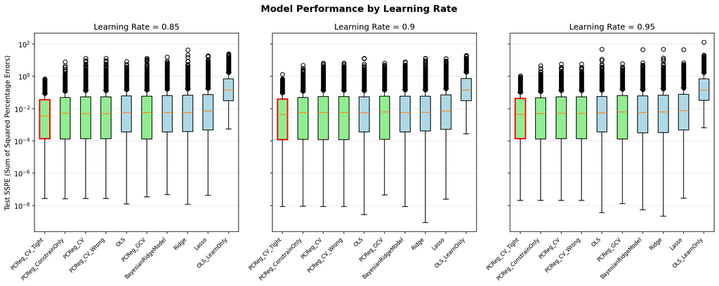

### Winners by Learning Rate

| Learning Rate | Winner | Mean SSPE |
| --- | --- | --- |
| 0.85 | PCReg_CV_Tight | 0.0407 |
| 0.9 | PCReg_CV_Tight | 0.0418 |
| 0.95 | PCReg_CV_Tight | 0.0464 |

### Mean test_sspe by Learning Rate and Model

| model_name learning_rate | BayesianRidgeModel | Lasso | OLS | OLS_LearnOnly | PCReg_CV | PCReg_CV_Tight | PCReg_CV_Wrong | PCReg_ConstrainOnly | PCReg_GCV | Ridge |
| --- | --- | --- | --- | --- | --- | --- | --- | --- | --- | --- |
| 0.8500 | 0.1455 | 0.2328 | 0.1023 | 0.8518 | 0.1271 | 0.0407 | 0.1278 | 0.0845 | 0.1381 | 0.1700 |
| 0.9000 | 0.1245 | 0.1800 | 0.1050 | 0.8244 | 0.1093 | 0.0418 | 0.1089 | 0.0784 | 0.1192 | 0.1411 |
| 0.9500 | 0.1527 | 0.1913 | 0.1366 | 0.9212 | 0.0911 | 0.0464 | 0.0914 | 0.0766 | 0.1087 | 0.1629 |

### Detailed Statistics

**Click to expand full statistics table**

| learning_rate | model_name | count | mean | std | min | 25% | 50% | 75% | max |
| --- | --- | --- | --- | --- | --- | --- | --- | --- | --- |
| 0.8500 | BayesianRidgeModel | 2025.0000 | 0.1455 | 0.6366 | 0.0000 | 0.0004 | 0.0057 | 0.0650 | 15.9270 |
|  | Lasso | 2025.0000 | 0.2328 | 1.1064 | 0.0000 | 0.0005 | 0.0072 | 0.0725 | 19.3317 |
|  | OLS | 2025.0000 | 0.1023 | 0.3684 | 0.0000 | 0.0004 | 0.0055 | 0.0603 | 8.2138 |
|  | OLS_LearnOnly | 2025.0000 | 0.8518 | 1.9953 | 0.0005 | 0.0308 | 0.1429 | 0.7087 | 24.6824 |
|  | PCReg_CV | 2025.0000 | 0.1271 | 0.5806 | 0.0000 | 0.0001 | 0.0050 | 0.0536 | 13.4309 |
|  | PCReg_CV_Tight | 2025.0000 | 0.0407 | 0.0837 | 0.0000 | 0.0001 | 0.0036 | 0.0354 | 0.6886 |
|  | PCReg_CV_Wrong | 2025.0000 | 0.1278 | 0.5816 | 0.0000 | 0.0001 | 0.0050 | 0.0529 | 13.4309 |
|  | PCReg_ConstrainOnly | 2025.0000 | 0.0845 | 0.3090 | 0.0000 | 0.0001 | 0.0052 | 0.0481 | 7.9484 |
|  | PCReg_GCV | 2025.0000 | 0.1381 | 0.6489 | 0.0000 | 0.0001 | 0.0057 | 0.0580 | 13.4309 |
|  | Ridge | 2025.0000 | 0.1700 | 1.2322 | 0.0000 | 0.0004 | 0.0056 | 0.0686 | 44.0540 |
| 0.9000 | BayesianRidgeModel | 2025.0000 | 0.1245 | 0.4644 | 0.0000 | 0.0004 | 0.0056 | 0.0590 | 7.7968 |
|  | Lasso | 2025.0000 | 0.1800 | 0.6986 | 0.0000 | 0.0005 | 0.0069 | 0.0698 | 12.8673 |
|  | OLS | 2025.0000 | 0.1050 | 0.5162 | 0.0000 | 0.0004 | 0.0054 | 0.0533 | 13.0536 |
|  | OLS_LearnOnly | 2025.0000 | 0.8244 | 1.8246 | 0.0003 | 0.0314 | 0.1434 | 0.7394 | 19.9906 |
|  | PCReg_CV | 2025.0000 | 0.1093 | 0.3908 | 0.0000 | 0.0001 | 0.0057 | 0.0555 | 6.5164 |
|  | PCReg_CV_Tight | 2025.0000 | 0.0418 | 0.0892 | 0.0000 | 0.0001 | 0.0043 | 0.0393 | 1.3050 |
|  | PCReg_CV_Wrong | 2025.0000 | 0.1089 | 0.3903 | 0.0000 | 0.0001 | 0.0057 | 0.0552 | 6.5164 |
|  | PCReg_ConstrainOnly | 2025.0000 | 0.0784 | 0.2449 | 0.0000 | 0.0001 | 0.0056 | 0.0481 | 4.7624 |
|  | PCReg_GCV | 2025.0000 | 0.1192 | 0.4077 | 0.0000 | 0.0001 | 0.0063 | 0.0599 | 6.5637 |
|  | Ridge | 2025.0000 | 0.1411 | 0.6696 | 0.0000 | 0.0004 | 0.0058 | 0.0599 | 13.0418 |
| 0.9500 | BayesianRidgeModel | 2025.0000 | 0.1527 | 1.1096 | 0.0000 | 0.0003 | 0.0057 | 0.0616 | 46.4751 |
|  | Lasso | 2025.0000 | 0.1913 | 1.1460 | 0.0000 | 0.0005 | 0.0073 | 0.0782 | 46.5091 |
|  | OLS | 2025.0000 | 0.1366 | 1.1450 | 0.0000 | 0.0004 | 0.0055 | 0.0563 | 47.2520 |
|  | OLS_LearnOnly | 2025.0000 | 0.9212 | 3.4413 | 0.0006 | 0.0321 | 0.1395 | 0.7072 | 129.1258 |
|  | PCReg_CV | 2025.0000 | 0.0911 | 0.2800 | 0.0000 | 0.0001 | 0.0051 | 0.0532 | 5.9081 |
|  | PCReg_CV_Tight | 2025.0000 | 0.0464 | 0.0994 | 0.0000 | 0.0001 | 0.0043 | 0.0420 | 1.0406 |
|  | PCReg_CV_Wrong | 2025.0000 | 0.0914 | 0.2804 | 0.0000 | 0.0001 | 0.0051 | 0.0537 | 5.9081 |
|  | PCReg_ConstrainOnly | 2025.0000 | 0.0766 | 0.2306 | 0.0000 | 0.0001 | 0.0050 | 0.0465 | 4.6295 |
|  | PCReg_GCV | 2025.0000 | 0.1087 | 0.3218 | 0.0000 | 0.0001 | 0.0061 | 0.0650 | 5.9548 |
|  | Ridge | 2025.0000 | 0.1629 | 1.1969 | 0.0000 | 0.0003 | 0.0061 | 0.0681 | 47.1783 |

## Analysis by Rate Effect

Values: [np.float64(0.8), np.float64(0.85), np.float64(0.9)]

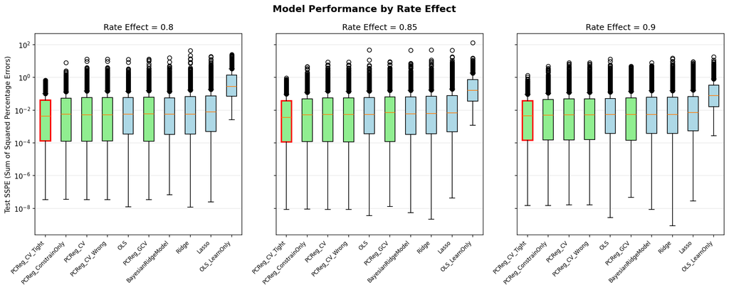

### Winners by Rate Effect

| Rate Effect | Winner | Mean SSPE |
| --- | --- | --- |
| 0.8 | PCReg_CV_Tight | 0.0433 |
| 0.85 | PCReg_CV_Tight | 0.0417 |
| 0.9 | PCReg_CV_Tight | 0.0439 |

### Mean test_sspe by Rate Effect and Model

| model_name rate_effect | BayesianRidgeModel | Lasso | OLS | OLS_LearnOnly | PCReg_CV | PCReg_CV_Tight | PCReg_CV_Wrong | PCReg_ConstrainOnly | PCReg_GCV | Ridge |
| --- | --- | --- | --- | --- | --- | --- | --- | --- | --- | --- |
| 0.8000 | 0.1177 | 0.1746 | 0.0967 | 1.4635 | 0.1061 | 0.0433 | 0.1061 | 0.0775 | 0.1179 | 0.1529 |
| 0.8500 | 0.1544 | 0.2289 | 0.1256 | 0.7852 | 0.1086 | 0.0417 | 0.1086 | 0.0813 | 0.1221 | 0.1568 |
| 0.9000 | 0.1505 | 0.2006 | 0.1216 | 0.3487 | 0.1128 | 0.0439 | 0.1134 | 0.0806 | 0.1260 | 0.1642 |

### Detailed Statistics

**Click to expand full statistics table**

| rate_effect | model_name | count | mean | std | min | 25% | 50% | 75% | max |
| --- | --- | --- | --- | --- | --- | --- | --- | --- | --- |
| 0.8000 | BayesianRidgeModel | 2025.0000 | 0.1177 | 0.5306 | 0.0000 | 0.0003 | 0.0057 | 0.0559 | 15.9270 |
|  | Lasso | 2025.0000 | 0.1746 | 0.8504 | 0.0000 | 0.0005 | 0.0078 | 0.0755 | 19.3317 |
|  | OLS | 2025.0000 | 0.0967 | 0.4132 | 0.0000 | 0.0003 | 0.0056 | 0.0577 | 12.7770 |
|  | OLS_LearnOnly | 2025.0000 | 1.4635 | 2.7780 | 0.0026 | 0.0690 | 0.2762 | 1.3937 | 24.6824 |
|  | PCReg_CV | 2025.0000 | 0.1061 | 0.4638 | 0.0000 | 0.0001 | 0.0051 | 0.0580 | 13.4309 |
|  | PCReg_CV_Tight | 2025.0000 | 0.0433 | 0.0895 | 0.0000 | 0.0001 | 0.0043 | 0.0410 | 0.6818 |
|  | PCReg_CV_Wrong | 2025.0000 | 0.1061 | 0.4641 | 0.0000 | 0.0001 | 0.0052 | 0.0581 | 13.4309 |
|  | PCReg_ConstrainOnly | 2025.0000 | 0.0775 | 0.2634 | 0.0000 | 0.0001 | 0.0055 | 0.0525 | 7.9484 |
|  | PCReg_GCV | 2025.0000 | 0.1179 | 0.5591 | 0.0000 | 0.0001 | 0.0058 | 0.0612 | 13.4309 |
|  | Ridge | 2025.0000 | 0.1529 | 1.2222 | 0.0000 | 0.0003 | 0.0058 | 0.0666 | 44.0540 |
| 0.8500 | BayesianRidgeModel | 2025.0000 | 0.1544 | 1.1447 | 0.0000 | 0.0003 | 0.0059 | 0.0655 | 46.4751 |
|  | Lasso | 2025.0000 | 0.2289 | 1.3528 | 0.0000 | 0.0005 | 0.0068 | 0.0769 | 46.5091 |
|  | OLS | 2025.0000 | 0.1256 | 1.1221 | 0.0000 | 0.0004 | 0.0053 | 0.0592 | 47.2520 |
|  | OLS_LearnOnly | 2025.0000 | 0.7852 | 3.1684 | 0.0012 | 0.0350 | 0.1586 | 0.7461 | 129.1258 |
|  | PCReg_CV | 2025.0000 | 0.1086 | 0.4101 | 0.0000 | 0.0001 | 0.0053 | 0.0573 | 8.8710 |
|  | PCReg_CV_Tight | 2025.0000 | 0.0417 | 0.0884 | 0.0000 | 0.0001 | 0.0035 | 0.0378 | 0.9044 |
|  | PCReg_CV_Wrong | 2025.0000 | 0.1086 | 0.4104 | 0.0000 | 0.0001 | 0.0055 | 0.0566 | 8.8710 |
|  | PCReg_ConstrainOnly | 2025.0000 | 0.0813 | 0.2585 | 0.0000 | 0.0001 | 0.0052 | 0.0481 | 4.6295 |
|  | PCReg_GCV | 2025.0000 | 0.1221 | 0.4560 | 0.0000 | 0.0001 | 0.0070 | 0.0647 | 9.1772 |
|  | Ridge | 2025.0000 | 0.1568 | 1.1801 | 0.0000 | 0.0004 | 0.0061 | 0.0692 | 47.1783 |
| 0.9000 | BayesianRidgeModel | 2025.0000 | 0.1505 | 0.5099 | 0.0000 | 0.0004 | 0.0055 | 0.0620 | 7.7968 |
|  | Lasso | 2025.0000 | 0.2006 | 0.6873 | 0.0000 | 0.0005 | 0.0070 | 0.0670 | 9.1215 |
|  | OLS | 2025.0000 | 0.1216 | 0.5325 | 0.0000 | 0.0004 | 0.0054 | 0.0509 | 13.0536 |
|  | OLS_LearnOnly | 2025.0000 | 0.3487 | 0.8778 | 0.0003 | 0.0161 | 0.0756 | 0.3298 | 18.5575 |
|  | PCReg_CV | 2025.0000 | 0.1128 | 0.4307 | 0.0000 | 0.0002 | 0.0052 | 0.0480 | 8.1085 |
|  | PCReg_CV_Tight | 2025.0000 | 0.0439 | 0.0951 | 0.0000 | 0.0001 | 0.0045 | 0.0376 | 1.3050 |
|  | PCReg_CV_Wrong | 2025.0000 | 0.1134 | 0.4314 | 0.0000 | 0.0002 | 0.0051 | 0.0484 | 8.1085 |
|  | PCReg_ConstrainOnly | 2025.0000 | 0.0806 | 0.2692 | 0.0000 | 0.0001 | 0.0050 | 0.0436 | 4.7624 |
|  | PCReg_GCV | 2025.0000 | 0.1260 | 0.4133 | 0.0000 | 0.0001 | 0.0054 | 0.0569 | 4.7831 |
|  | Ridge | 2025.0000 | 0.1642 | 0.7164 | 0.0000 | 0.0004 | 0.0055 | 0.0617 | 14.8769 |

## Winner Frequency Analysis

How often each model achieves the lowest test SSPE across all scenarios.

| Rank | Model | Win Count | Win % |
| --- | --- | --- | --- |
| 1 | PCReg_CV_Tight | 1516 | 25.0% |
| 2 | PCReg_ConstrainOnly | 1187 | 19.5% |
| 3 | Lasso | 720 | 11.9% |
| 4 | OLS | 646 | 10.6% |
| 5 | BayesianRidgeModel | 516 | 8.5% |
| 6 | PCReg_GCV | 366 | 6.0% |
| 7 | OLS_LearnOnly | 323 | 5.3% |
| 8 | Ridge | 304 | 5.0% |
| 9 | PCReg_CV | 277 | 4.6% |
| 10 | PCReg_CV_Wrong | 220 | 3.6% |

## Interaction Heatmaps

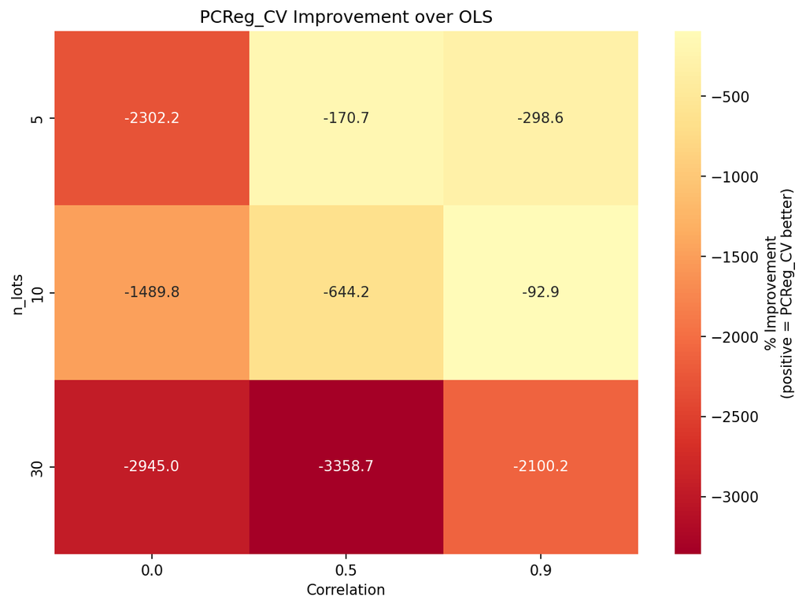

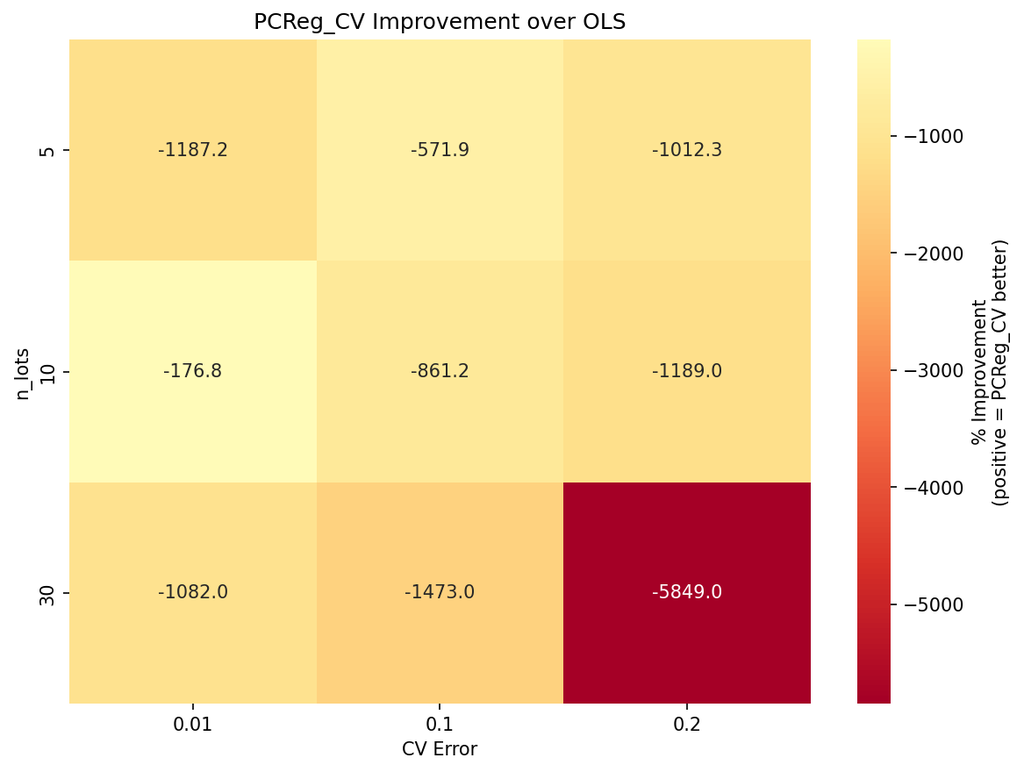

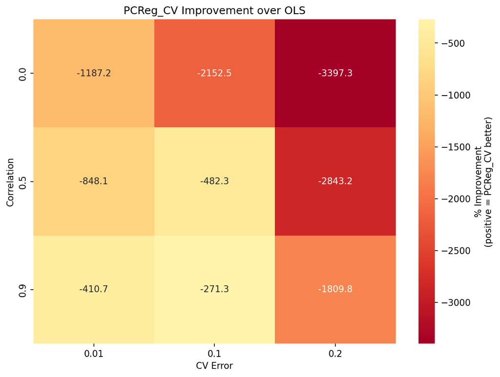